# Day 1, Session 3: Data Visualization in R

## geom_point: point color

- Let’s change the color of all points

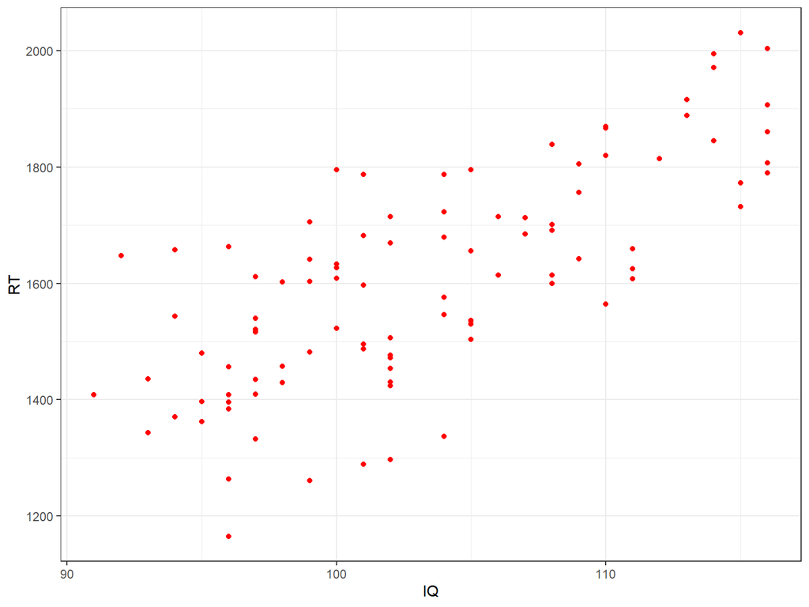

```r
g2 = g0 + geom_point(colour = "red")
g2
```

## geom_point: point shape

- Let’s change the shape of all points (there’s a “code table”)

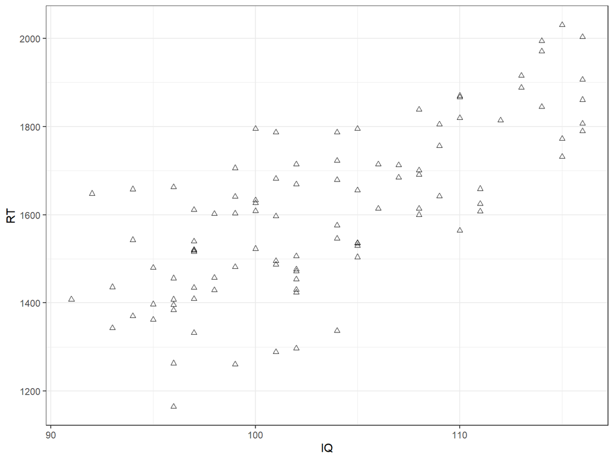

```r
g3 = g0 + geom_point(shape = 24)
g3
```

## geom_point: point size

- Let’s change the size of all points

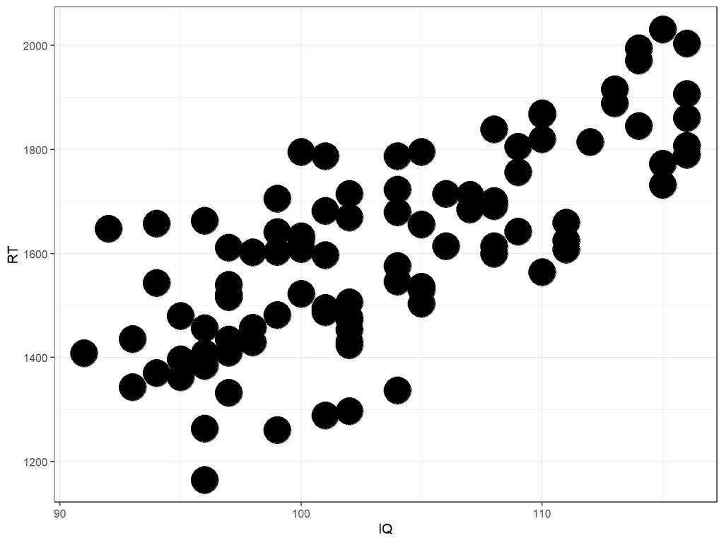

```r
g4 = g0 + geom_point(size = 10)
g4
```

## geom_point: point transparency

- Useful for big data, for overcrowded plots

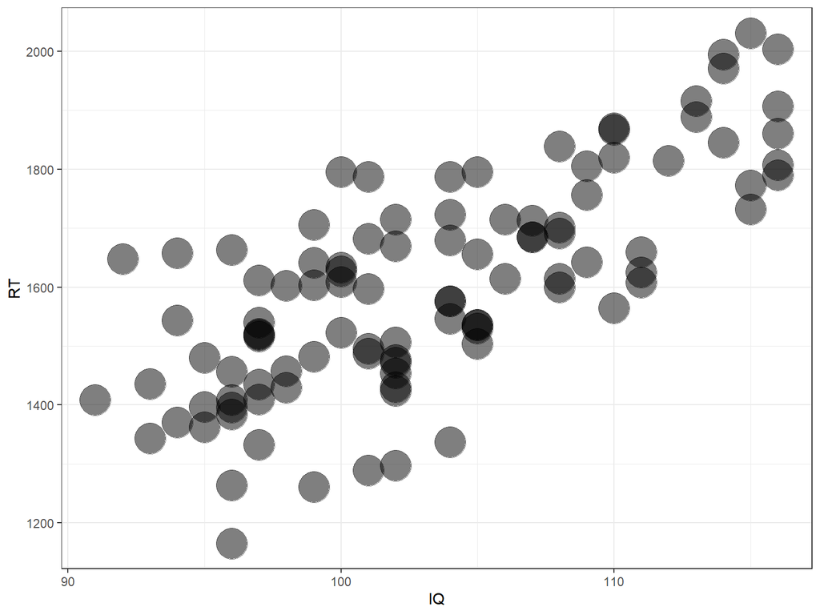

```r
g0 + geom_point(size = 10, alpha = 0.5)
```

## geom_point: “spreading out” the points

- Another solution for overcrowded plots

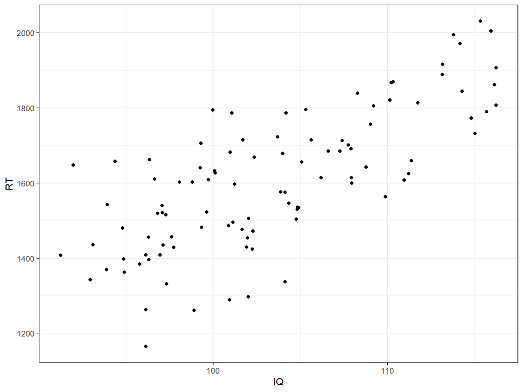

```r
g0 + geom_jitter()
```

- To make it reproducible (since jitter creates a slightly different result each time)

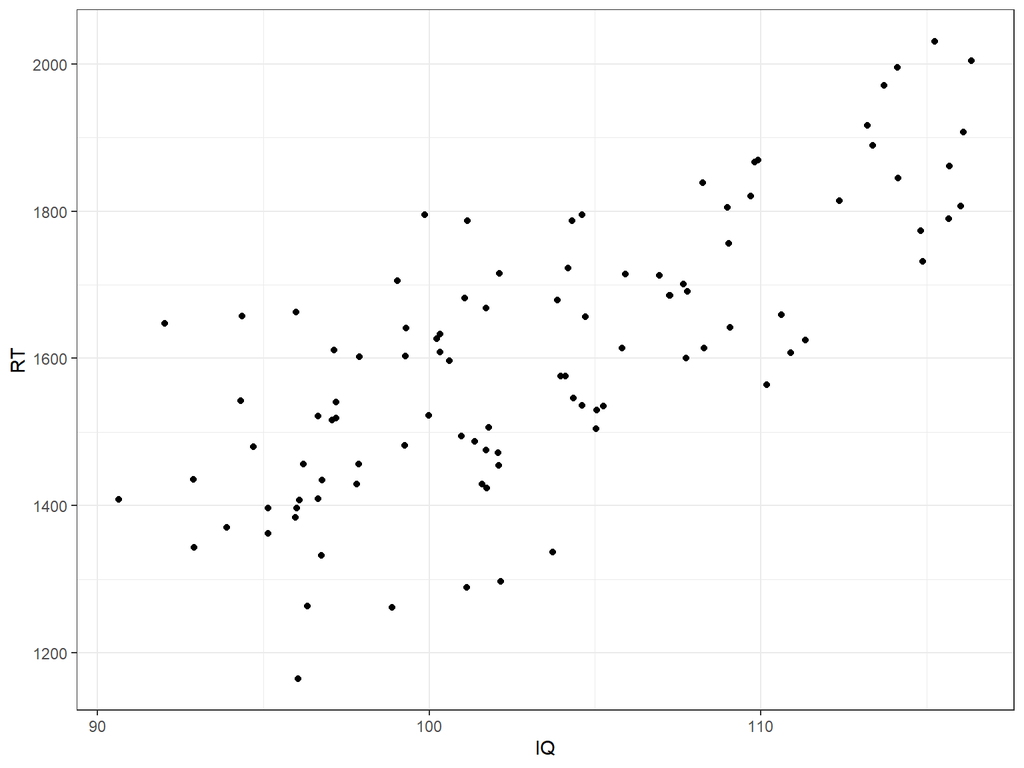

```r
g0 + geom_jitter(seed = 123)
```

## geom_point: let’s add the correlation coefficient to the plot

- First we load another package

[figure not shown]

```r
library(ggpubr)
g1 +
  stat_cor(method = "spearman", # choose the method
           label.x = 92, # specify the x-coordinate where the text should start
           label.y = 2000) # specify the y-coordinate where the text should start
```

## Regression line

- Just the line

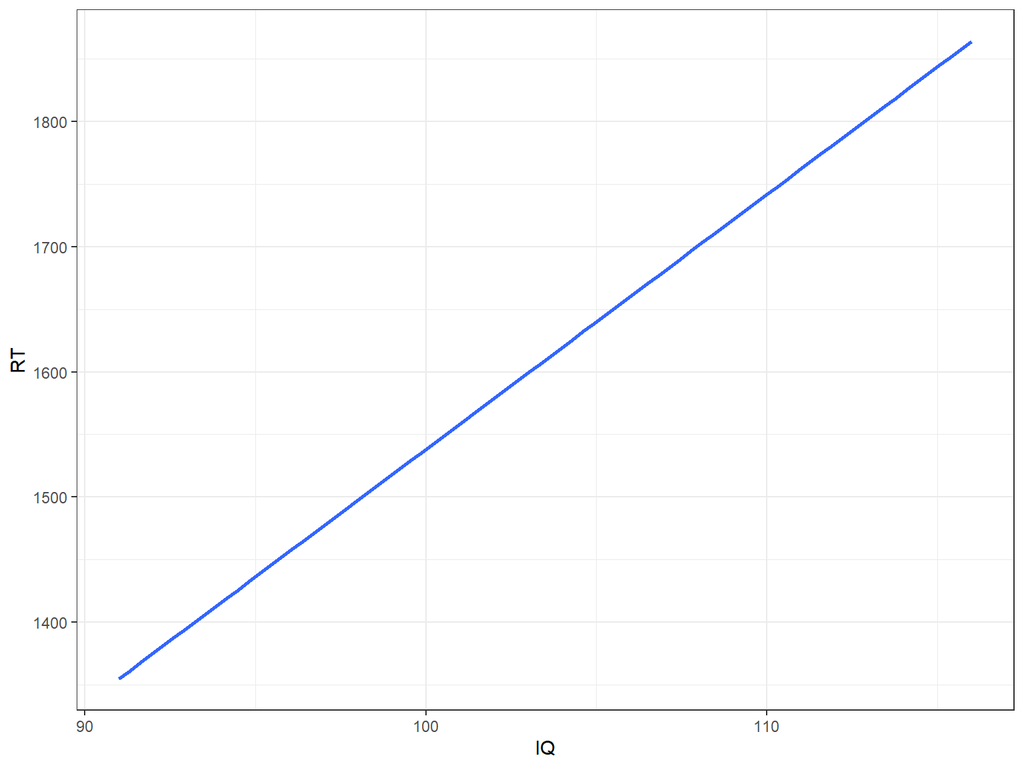

```r
g9 = g0 + geom_smooth(method = "lm", se = FALSE)
g9
```

## Regression line

- line and 95% CI

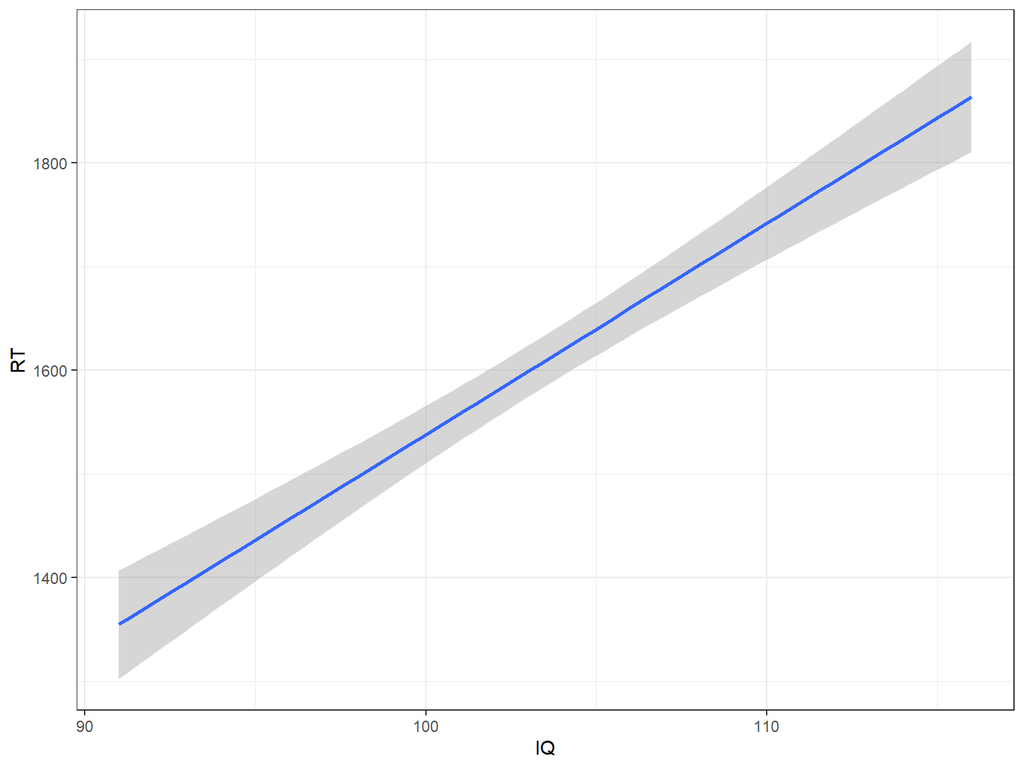

```r
g10 = g0 + geom_smooth(method = "lm", se = TRUE)
g10
```

## Prediction beyond the range of recorded values

- ggplot automatically draws the line only within the recorded range
- If we want extrapolation, we have to ask for it explicitly:

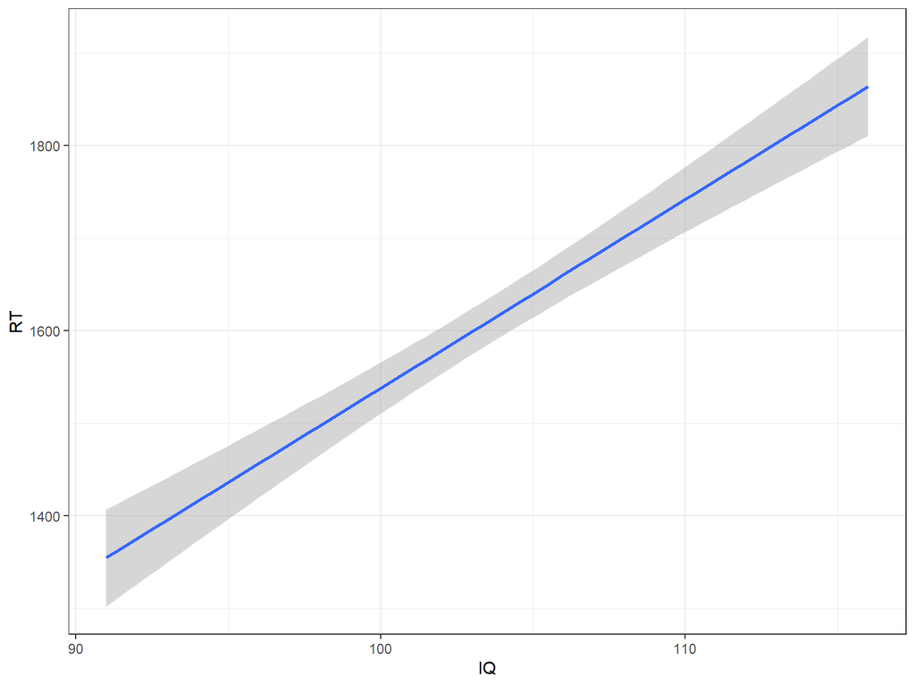

```r
g0 + geom_smooth(method = "lm", se = TRUE, fullrange=TRUE)
```

## Regression line

- Line, CI, and individual measurements

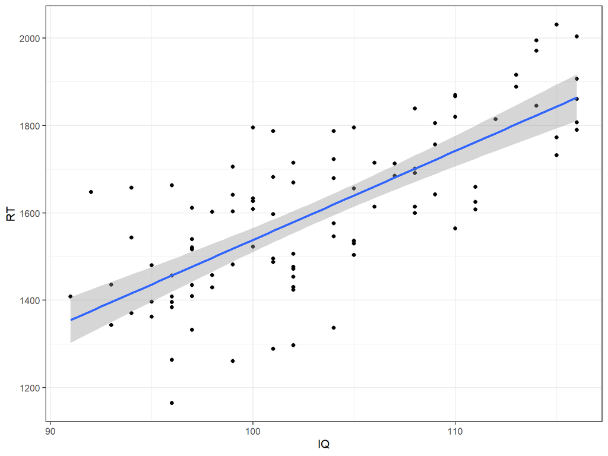

```r
g10 = g1 + geom_smooth(method = "lm", se = TRUE)
g10
```

## Regression “curve”

- For a quick look at non-linearity

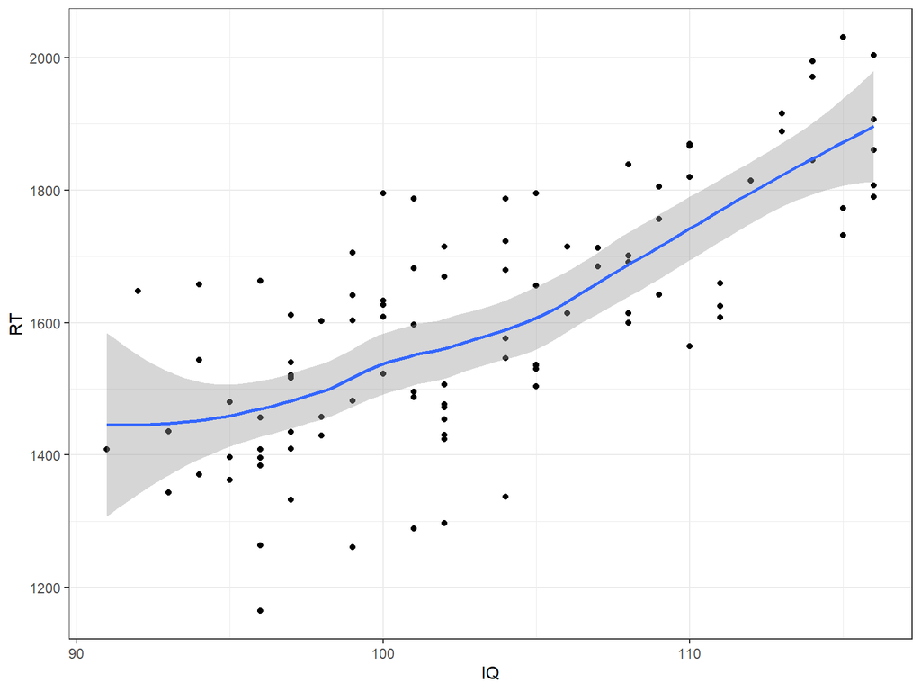

```r
g1 + geom_smooth(method = "loess", se = TRUE)
```

## Regression “curve”

- Shrink the window size used for computing local averages (allow more curviness)

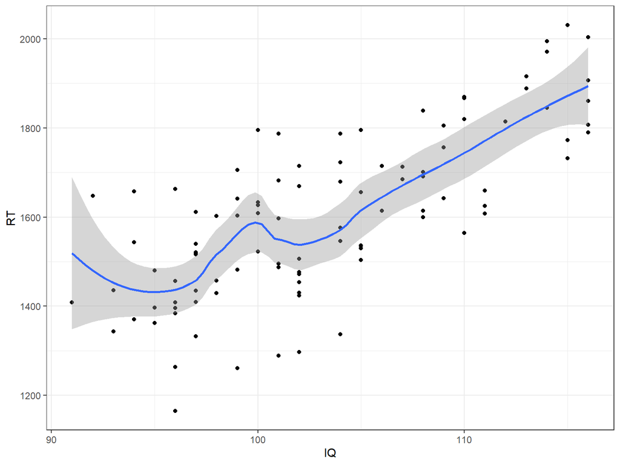

```r
g1 + geom_smooth(method = "loess", se = TRUE, span = 0.5)
```

## Regression “curve”

- Allow even more curviness

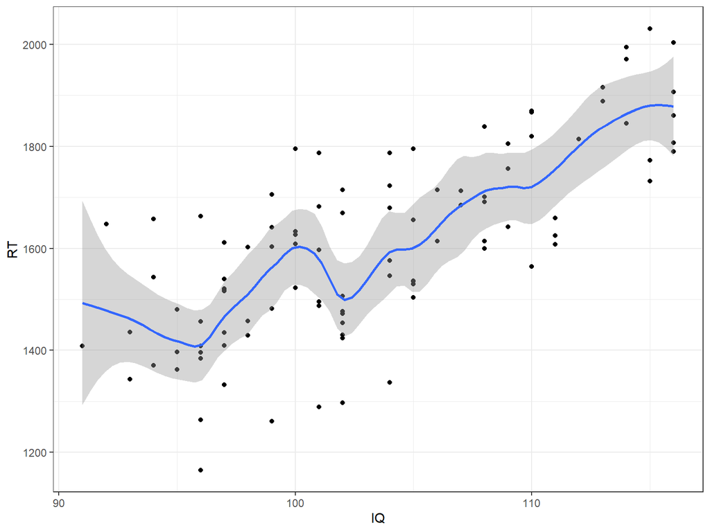

```r
g1 + geom_smooth(method = "loess", se = TRUE, span = 0.3)
```

## Now that we’ve had a first introduction to ggplot2, let’s take a more systematic look at the fundamentals

## The ggplot2 plot has several components:

- data
  - ideally a clean and tidy data frame
  - different layers can display different data
- aes
  - how variables are mapped onto visual characteristics
  - mapping variables onto axis coordinates, color, and size
- geom
  - the name of the geometric object used for drawing
  - the way each observation should be displayed (points, lines, bars…)
- stat
  - the type of statistical transformation to apply (identity, smooth…)
- position
  - the way overlap issues are resolved
  - how we organize elements within a plot (jittering, stacking, dodging)
  - also how we organize multiple plots within a single image (faceting)
- axes
  - how we label them, orient them, etc.
- coordinate system
  - we will work with the Cartesian one, but others exist
- themes
  - what general style we give the plot (classic, minimal…)

## Layer: data

## Layer: data

- The data we are visualizing
- Our data frame
- Typically the first argument of the ggplot() function

## Layer: aes

## Layer: aes

- Mapping variables onto visual characteristics
- The basic case: mapping variables onto the x and y axes (we’ve already seen this)

## Layer aes: point color

- Let’s make point color a function of some variable

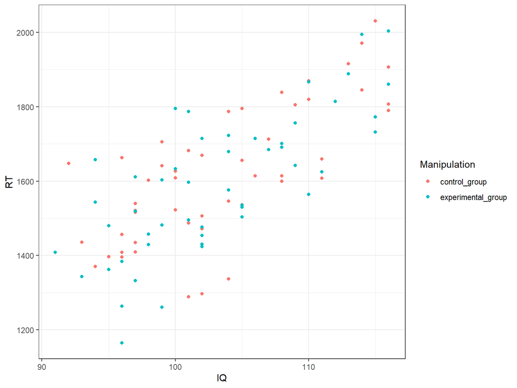

```r
g5 = g1 + aes(colour = Manipulation)
g5
```

- Choosing a pallette

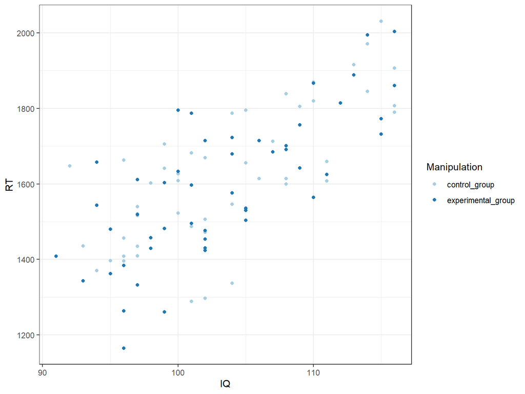

```r
library(RColorBrewer)
g1 + aes(colour = Manipulation) +
  scale_colour_brewer(palette = "Paired")
```

- To inspect existing pallettes

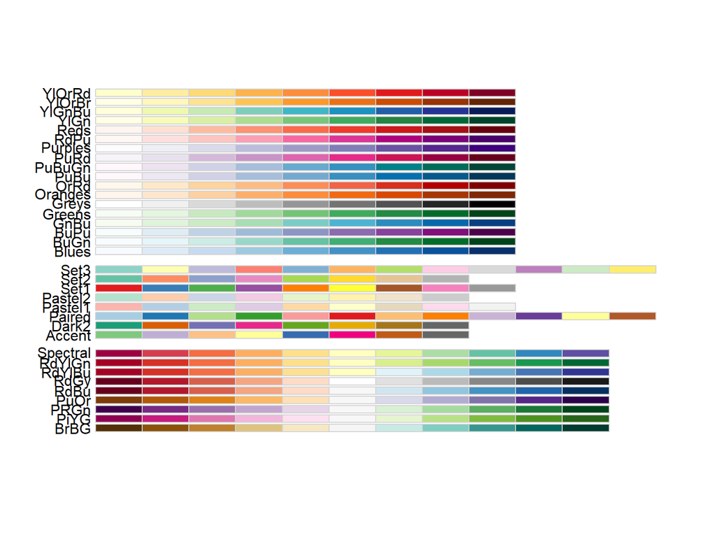

```r
library(RColorBrewer)
display.brewer.all() # every built-in palette
```

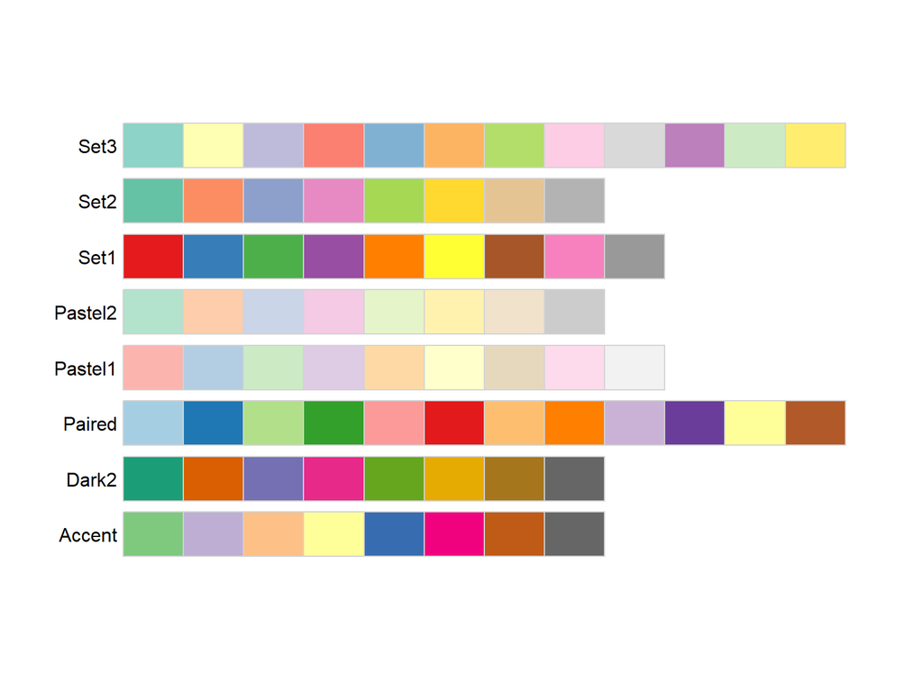

```r
display.brewer.all(type = "qual")  # filtered qualitative (categories)
```

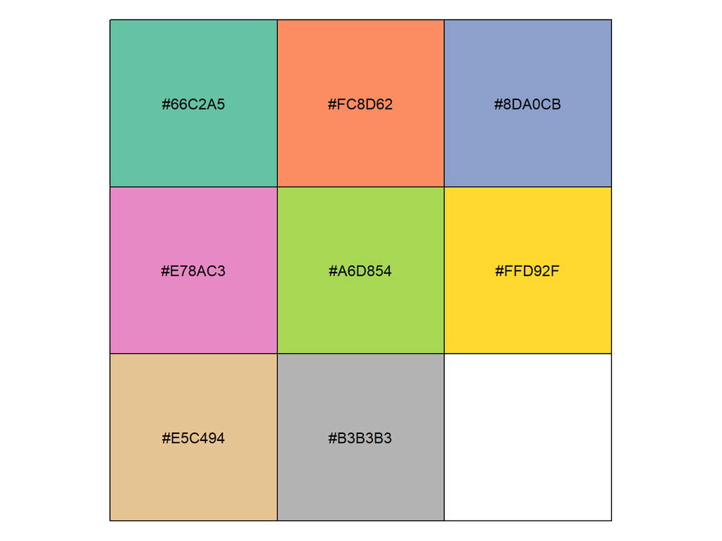

```r
library(scales)
show_col(brewer.pal(8, "Set2"))  # set of colours for 8 categories
```

- Let’s make the color color-blind-friendly

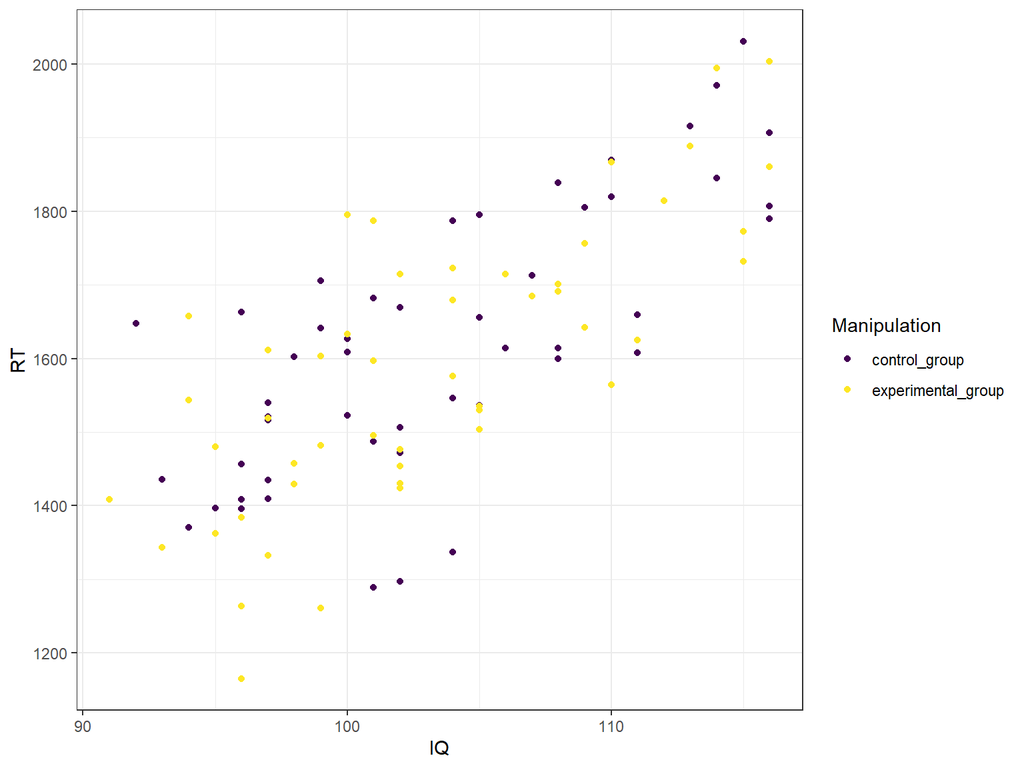

```r
library(viridis)
# choosing pallette options: A, B, C, D, E, F, G, H
g5 + scale_colour_viridis_d(option = "D")
```

- Choosing specific colors for specific levels

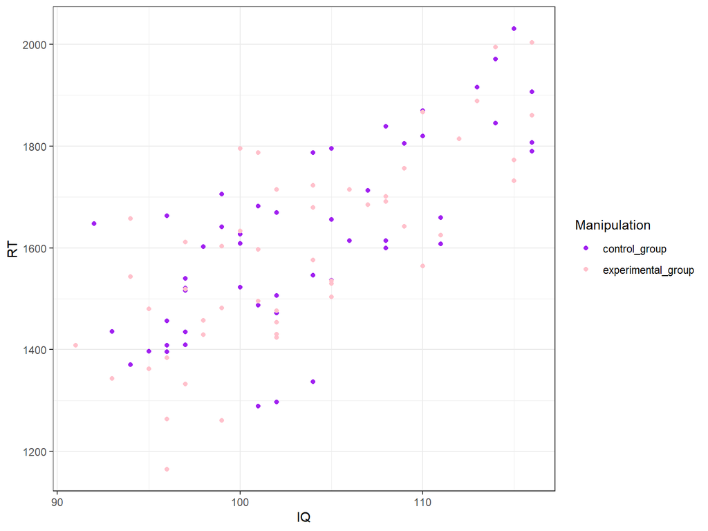

```r
g1 + aes(colour = Manipulation) +
  scale_colour_manual(values = c("control_group" = "purple", "experimental_group" = "pink"))
```

## Layer aes: point shape

- Let’s make point shape a function of some variable

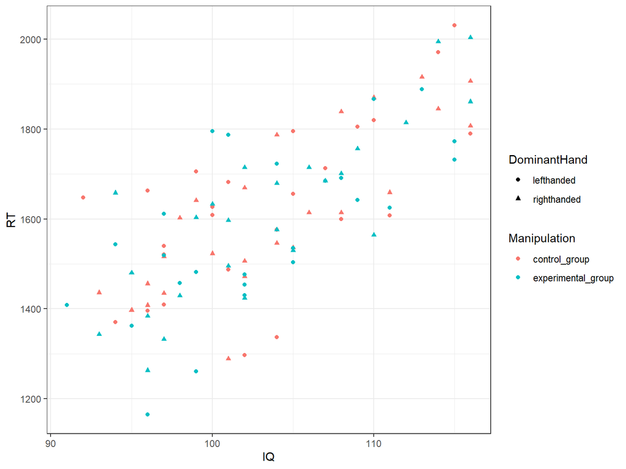

```r
g6 = g5 + aes(shape = DominantHand)
g6
```

## Layer aes: point size

- Let’s make point size a function of some variable

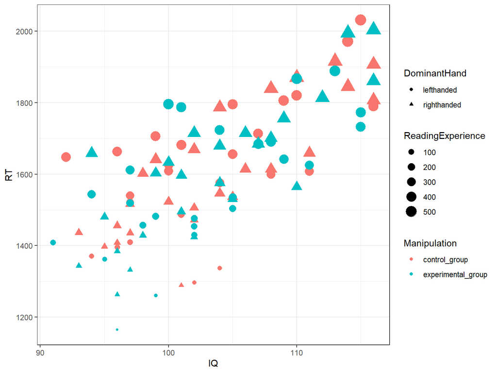

```r
g7 = g6 + aes(size = ReadingExperience)
g7
```

## Faceting

- Splitting into “sub-plots” based on the levels of one or more categorical variables

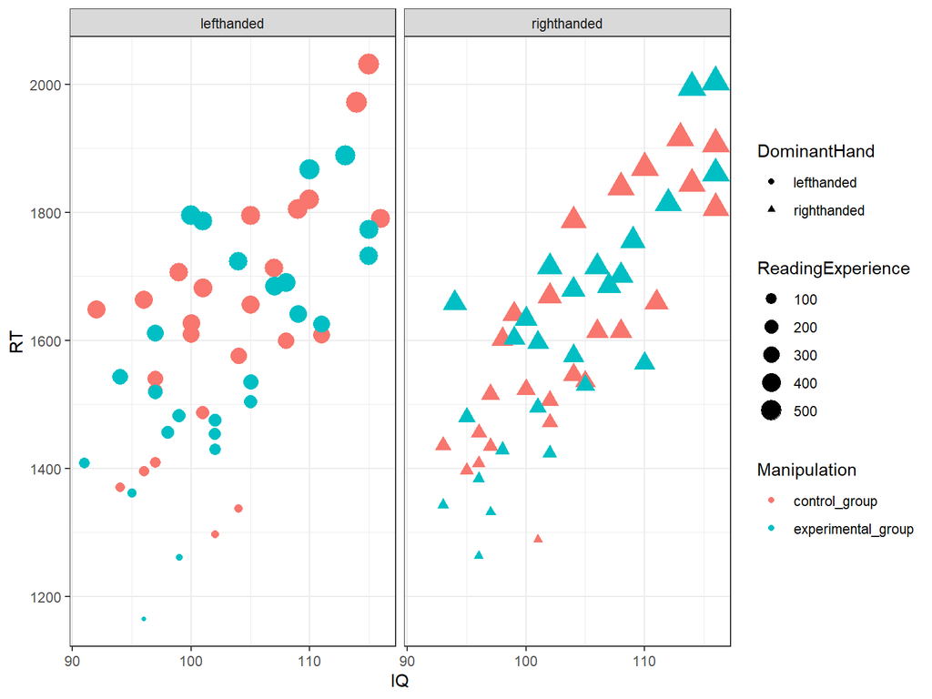

```r
g8 = g7 + facet_wrap(~DominantHand)
# for each level of the Handedness variable, make a separate plot,
# arrange them in a row, and "pack" them as neatly as possible
g8
```

## Faceting

- Similar, but levels arranged strictly by plot columns

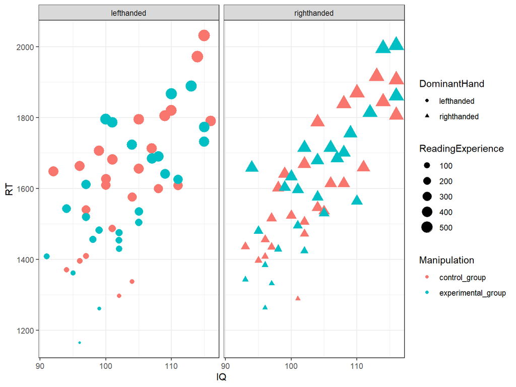

```r
g7 + facet_grid(.~DominantHand)
```

## Faceting

- Similar, but levels arranged strictly by plot rows

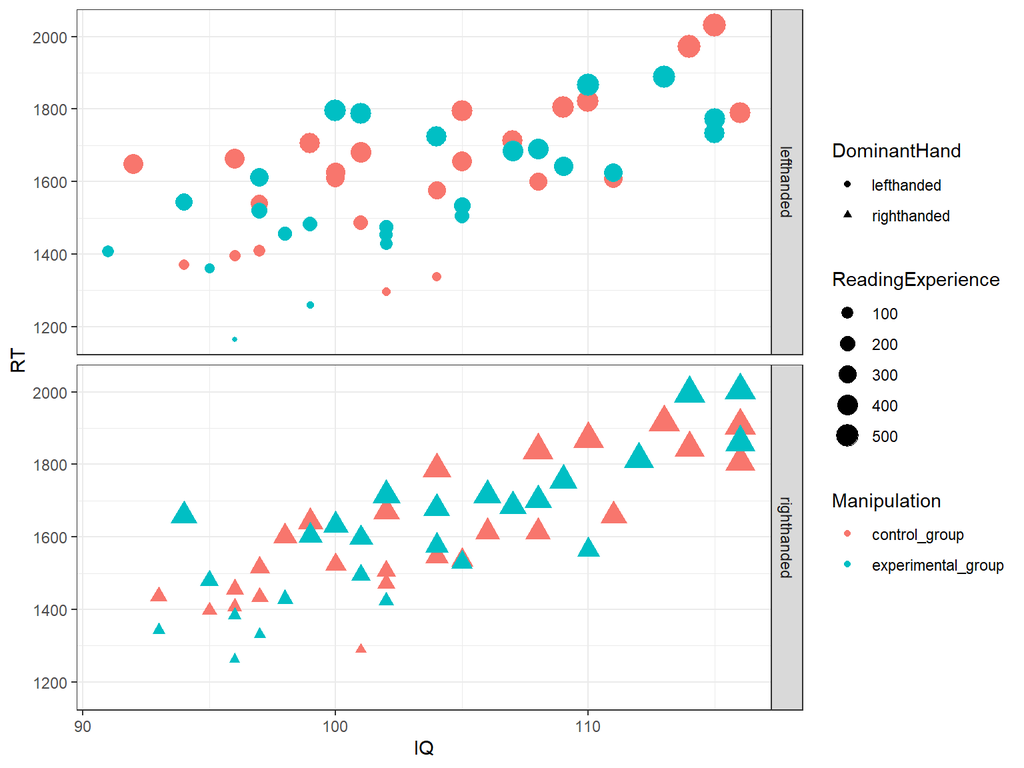

```r
g7 + facet_grid(DominantHand~.)
```

## Faceting

- Let’s make a matrix of plots:

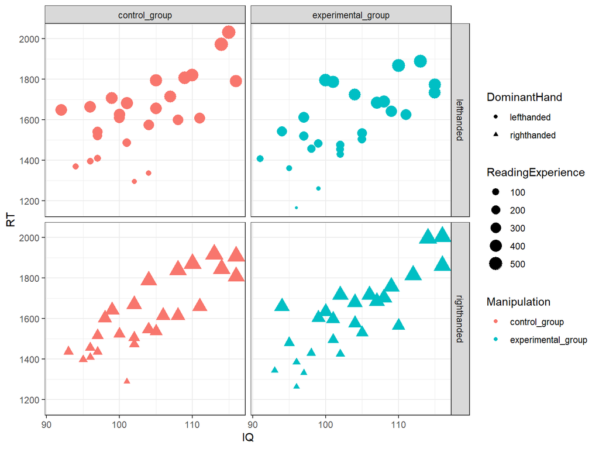

```r
g7 + facet_grid(DominantHand~Manipulation)
```

## A bit of wisdom: using color depending on the level at which aes() applies

- Points colored differently, but a single shared line

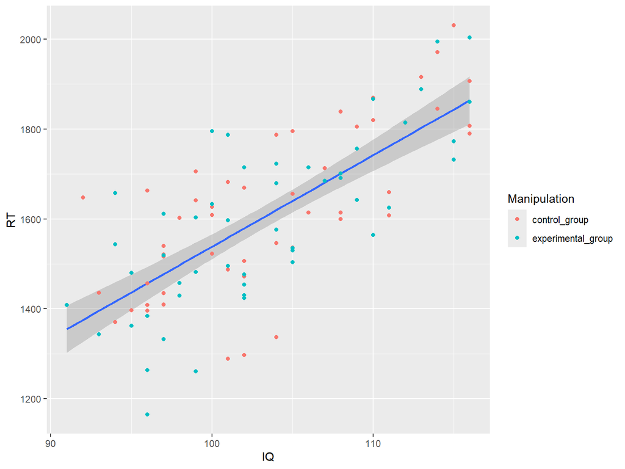

```r
ggplot(df, aes(x=IQ, y=RT)) +
            geom_smooth(method = "lm", se = TRUE) +
            geom_point(aes(colour = Manipulation))
```

```r
            # assign color to the aesthetic at the point level
```

## Using color depending on the level at which aes() applies

- Points colored differently, and separate lines

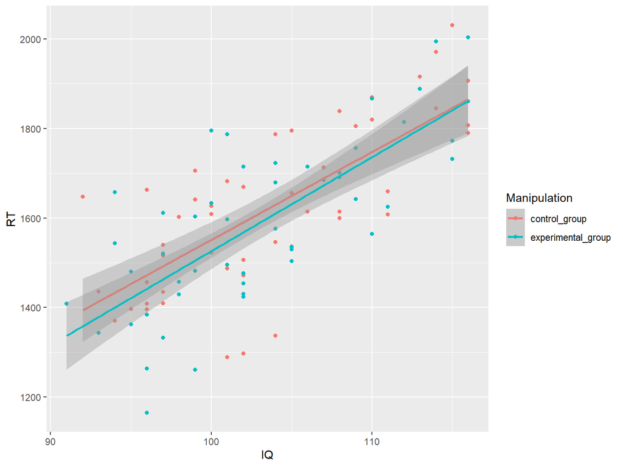

```r
ggplot(df, aes(x=IQ, y=RT, colour = Manipulation)) +
                        # assign color to the aesthetic at the global level
            geom_point() +
            geom_smooth(method = "lm", se = TRUE)
```

## Setting vs. mapping color: similar code, very different meaning

- Now we are setting the color (giving it a single fixed value ourselves)

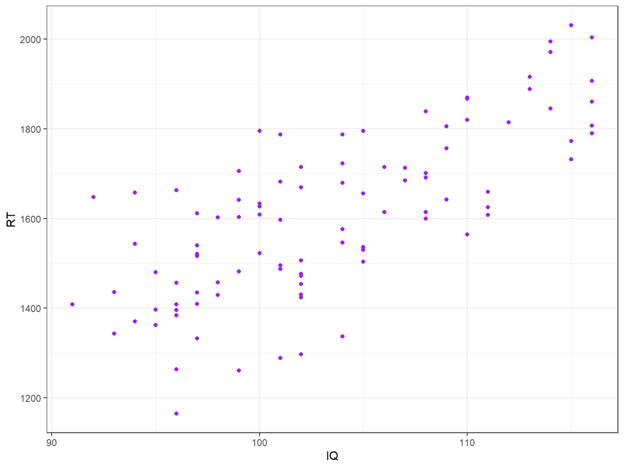

```r
g1+geom_point(colour = "purple")
```

## Now we are MAPPING color onto the value of some variable (aes deals with mapping variable values onto the visual domain, not with visual aspects themselves)

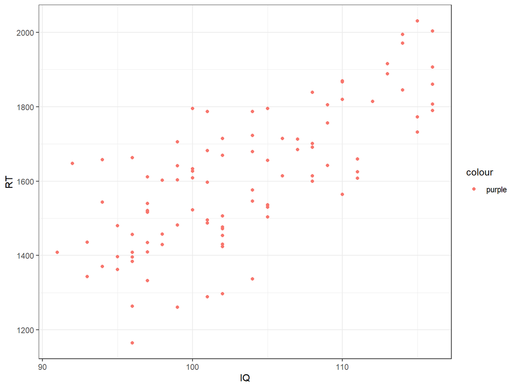

```r
g1+geom_point(aes(colour = "purple"))
```

> Since a variable is expected within aes, and no variable called “purple” exists, R created such a variable, because we asked it to map

## Sometimes it’s convenient to use color to compare regression lines

- Let’s create our own levels of a new variable to map colors onto

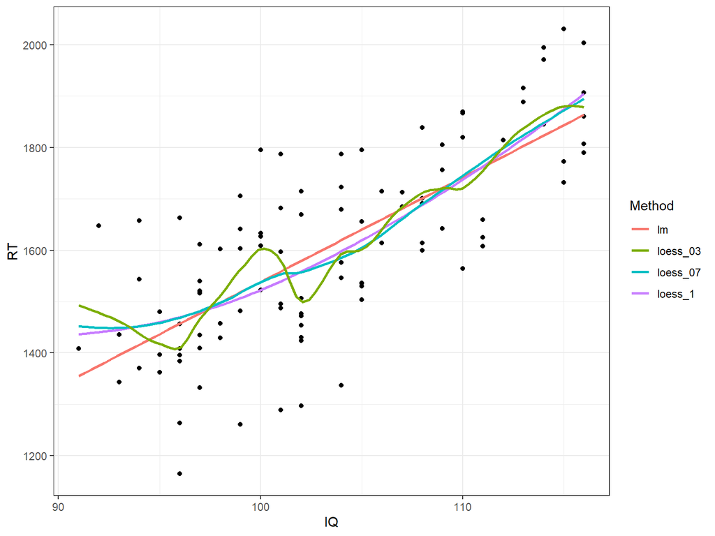

```r
g1 +
  geom_smooth(aes(colour = "lm"), method = "lm", se = FALSE) +
  geom_smooth(aes(colour = "loess_1"), method = "loess", span = 1, se = FALSE) +
  geom_smooth(aes(colour = "loess_07"), method = "loess", span = 0.7, se = FALSE) +
  geom_smooth(aes(colour = "loess_03"), method = "loess", span = 0.3, se = FALSE) +
  labs(colour = "Method")
```

## Layer: geom

## Layer: geom

- The geometric elements we use for drawing
- Instructions on how the values should be displayed
- As a rule: geom_typeofdisplay()

## Layer: geom

- Bars, one variable

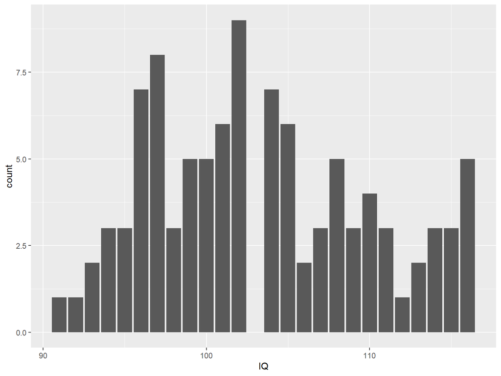

```r
ggplot(df, aes(x=IQ)) + geom_bar()
```

## Layer: geom

- Bars, two variables

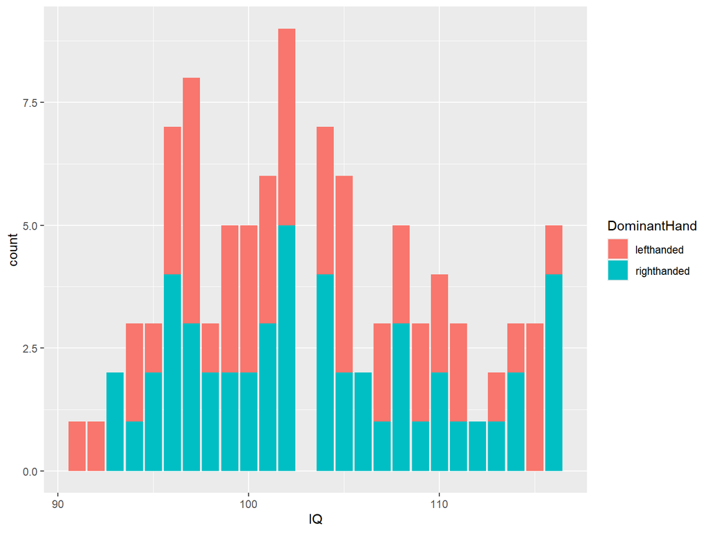

```r
ggplot(df, aes(x=IQ, fill=DominantHand)) + geom_bar()
```

## Layer: geom

- Bars, two variables, proportional

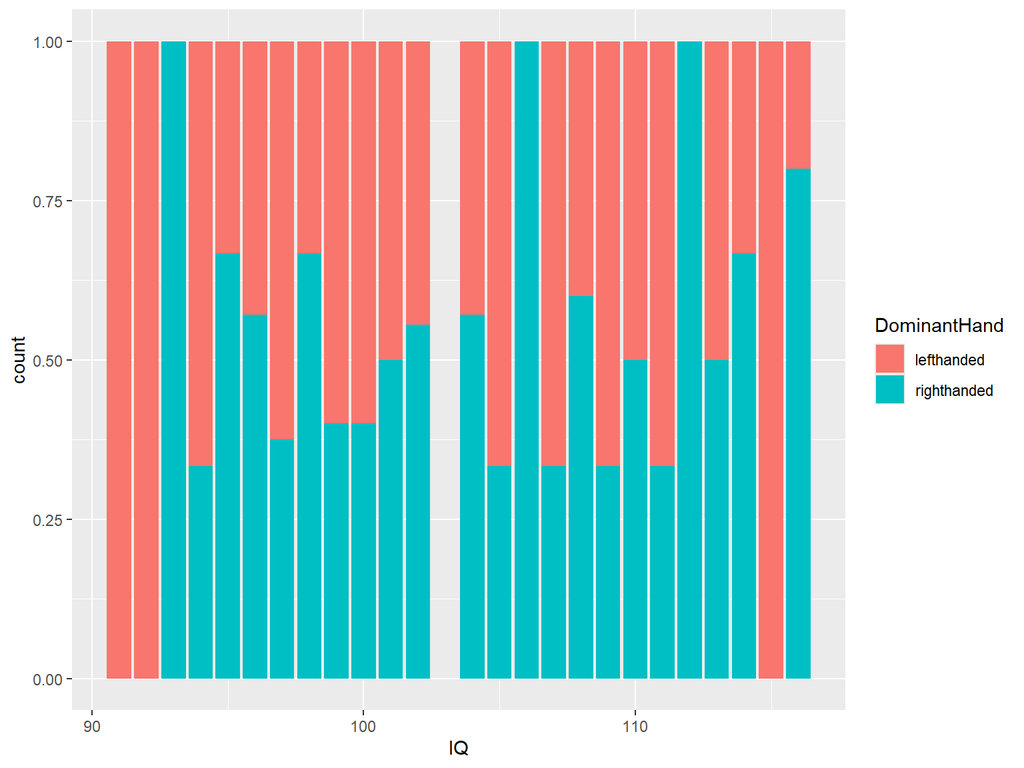

```r
ggplot(df, aes(x=IQ, fill=DominantHand)) + geom_bar(position="fill")
```

## Layer: geom

- Histogram, frequencies

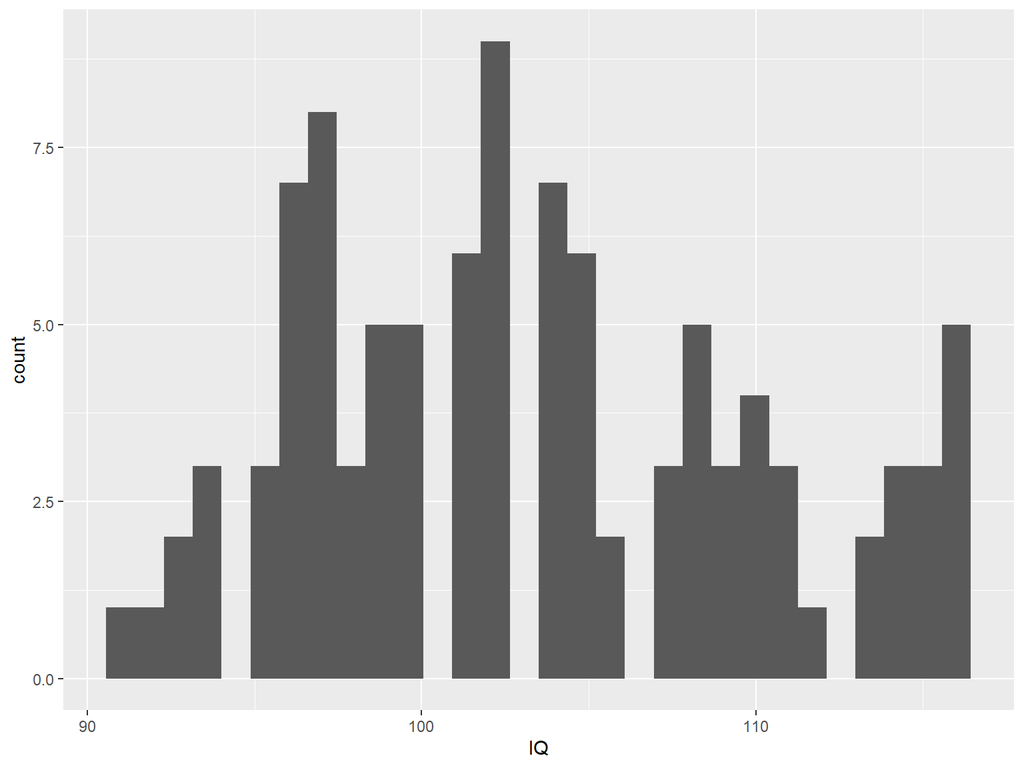

```r
ggplot(df, aes(IQ)) + geom_histogram()
```

## Layer: geom

- Histogram, probability density function

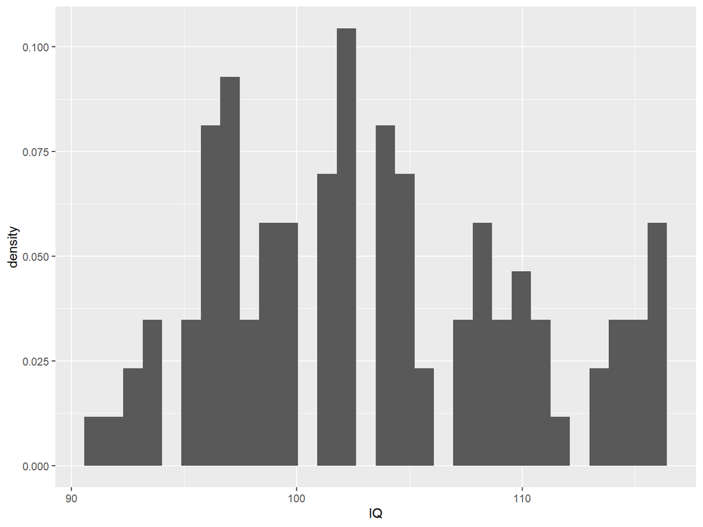

```r
ggplot(df, aes(IQ)) + geom_histogram(aes(y = after_stat(density)))
```

## Layer: geom

- Line, frequencies

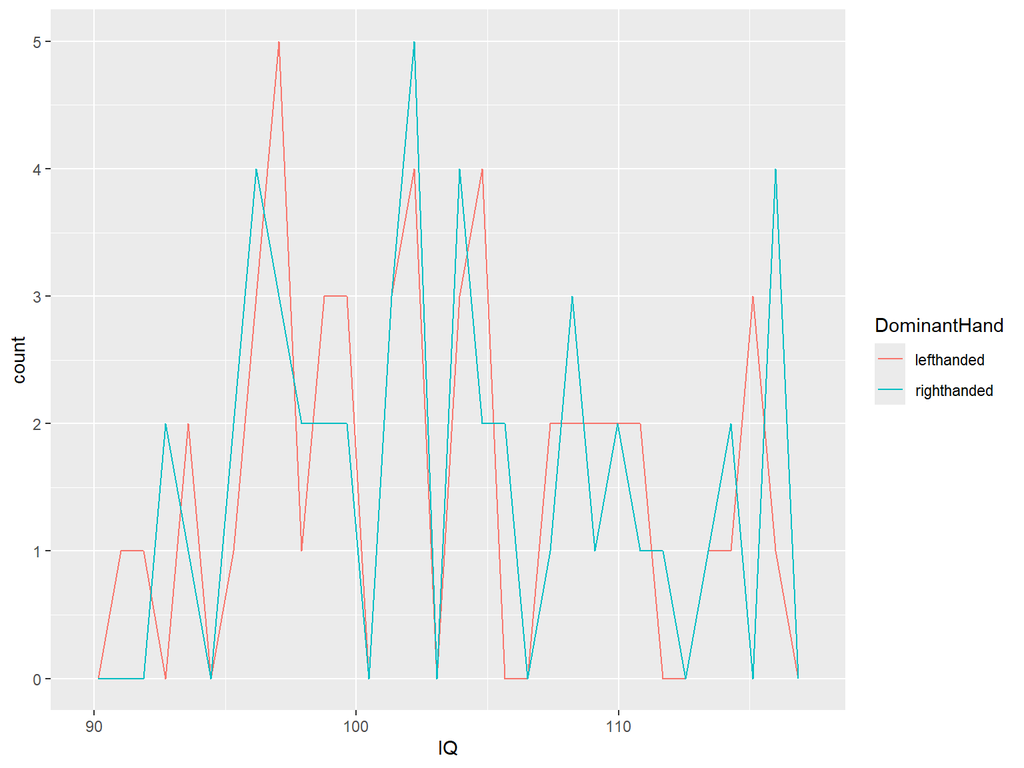

```r
ggplot(df, aes(IQ, colour = DominantHand)) + geom_freqpoly()
```

## Layer: geom

- Line, probability density function

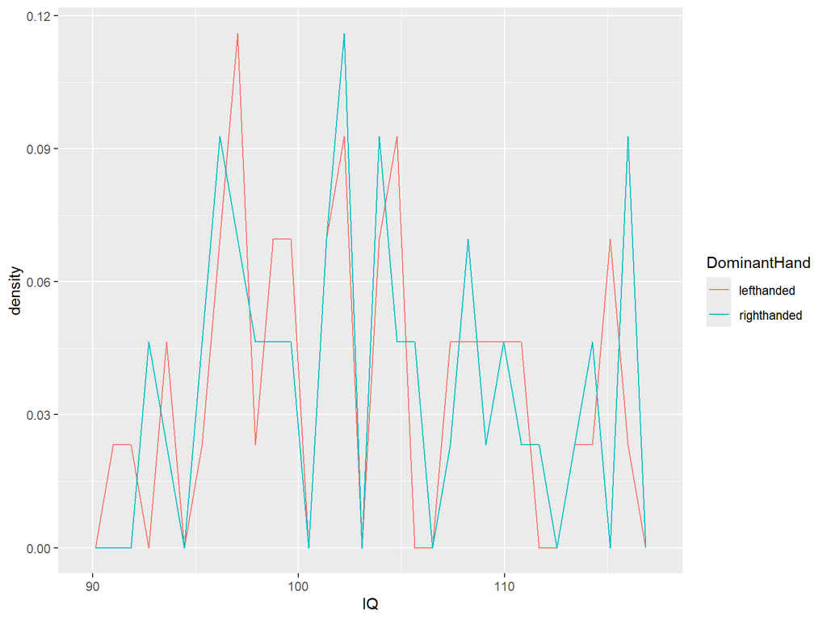

```r
ggplot(df, aes(IQ, colour = DominantHand)) + geom_freqpoly(aes(y = after_stat(density)))
```

## Layer: geom

- Probability density functions: overlapping, colored, semi-transparent areas

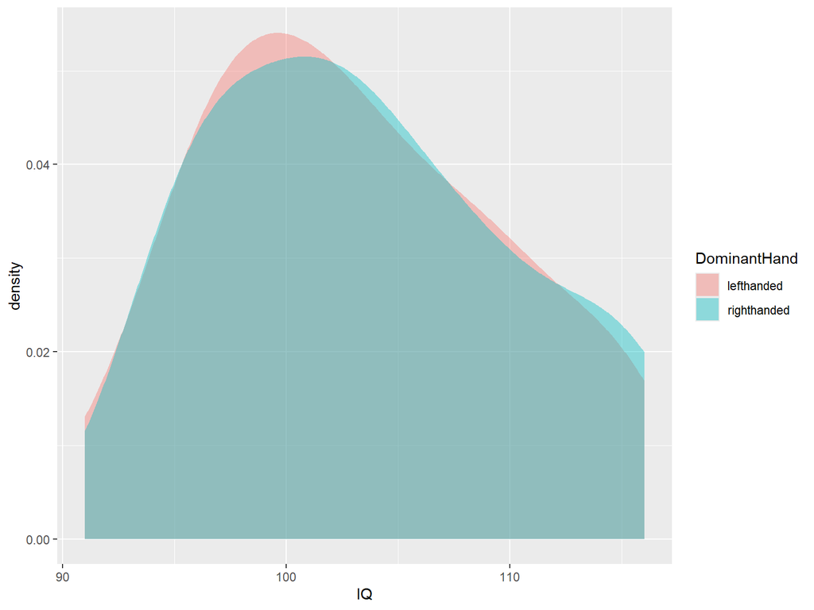

```r
ggplot(df, aes(IQ, fill = DominantHand)) + geom_density(col = NA, alpha = 0.4)
```

## Layer: geom

- 2D density function: topographic map

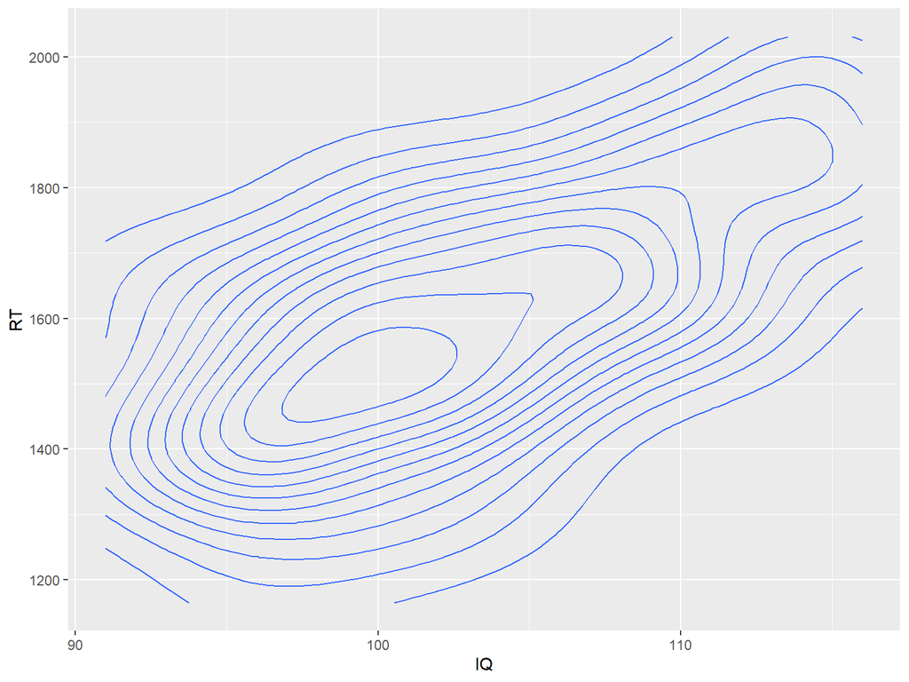

```r
ggplot(df, aes(x=IQ, y=RT)) + geom_density_2d()
```

## Layer: geom

- 2D density function, color/shading

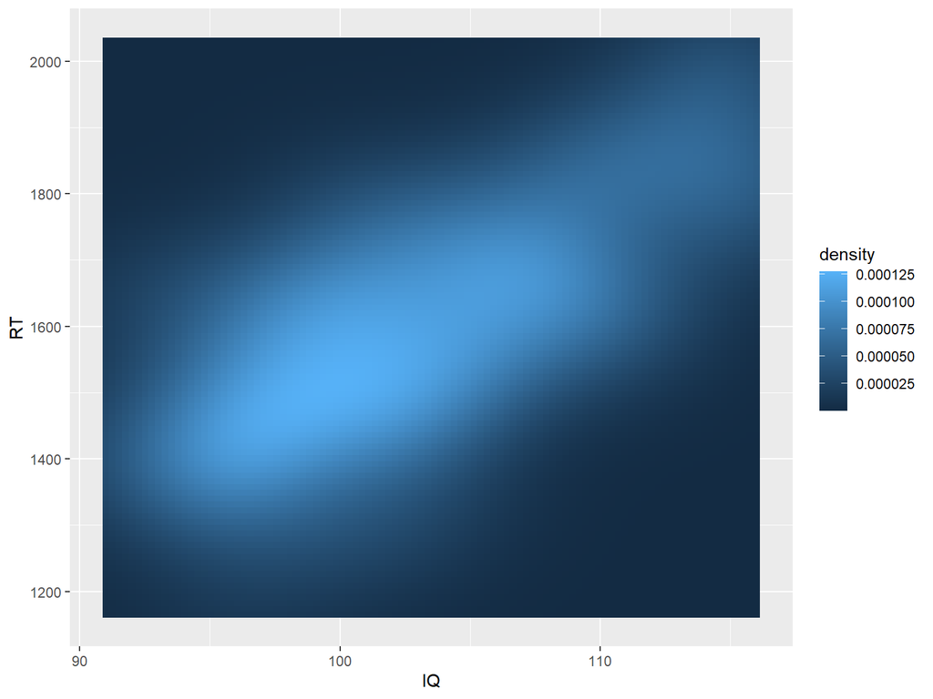

```r
ggplot(df, aes(x=IQ, y=RT)) + stat_density_2d(geom="tile", aes(fill=after_stat(density)), contour=FALSE)
```

## Layer: geom

- Box & whiskers

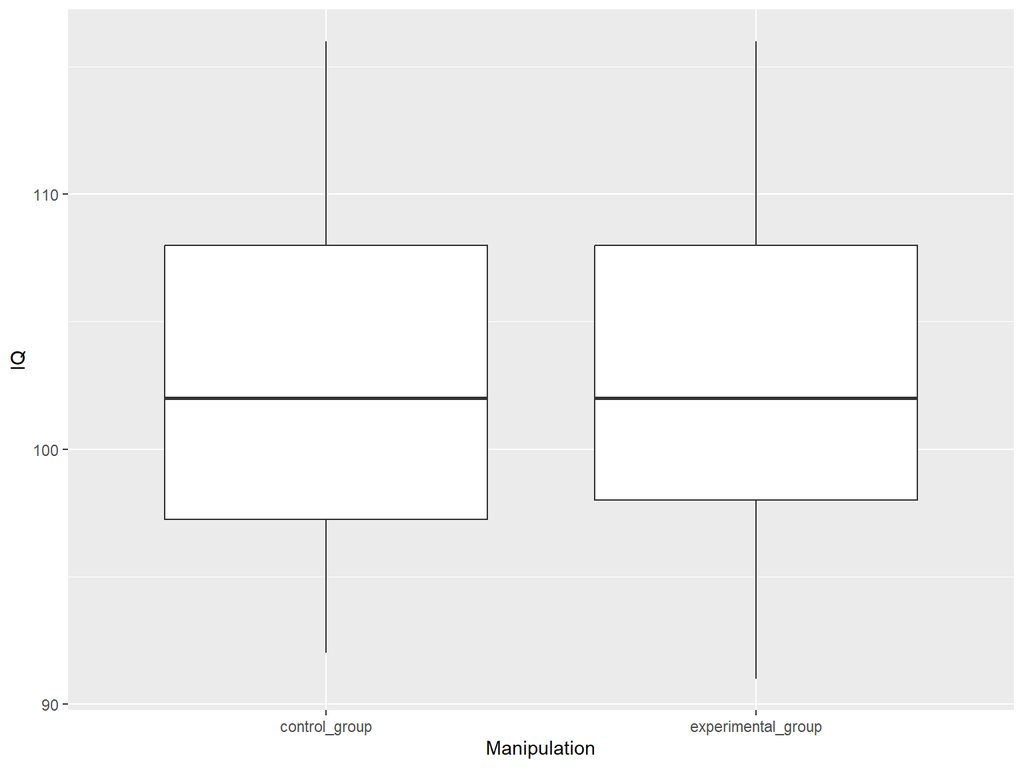

```r
ggplot(df, aes(x= Manipulation, y=IQ)) + geom_boxplot()
```

## Layer: geom

- Violin

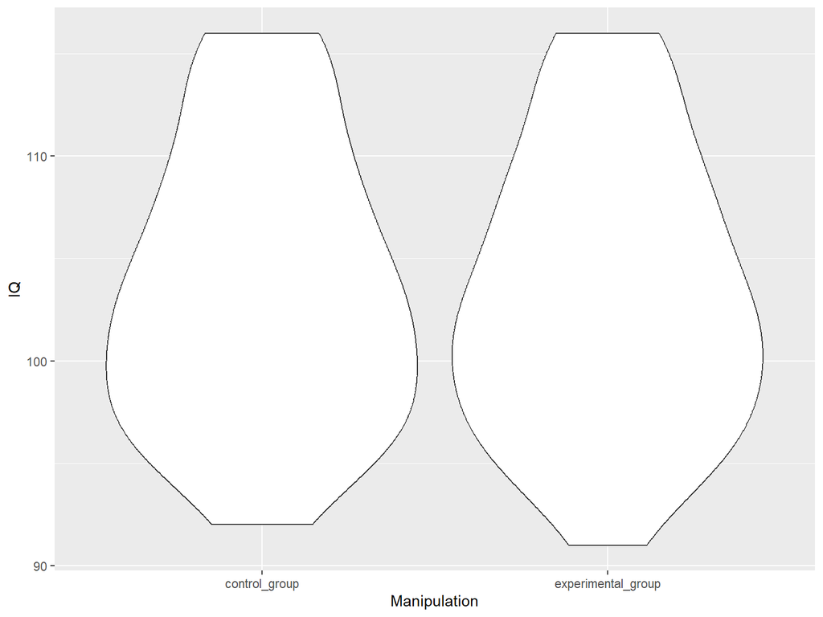

```r
ggplot(df, aes(x= Manipulation, y=IQ)) + geom_violin()
```

## Layer: geom

- We’ve already seen the scatterplot, let’s add a rug

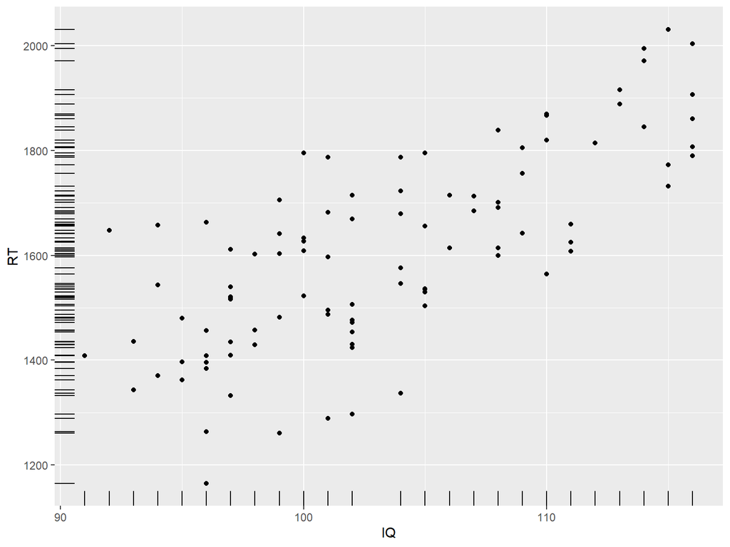

```r
ggplot(df, aes(x= IQ, y=RT)) + geom_point() + geom_rug()
```

## Layer: geom

- Text instead of points

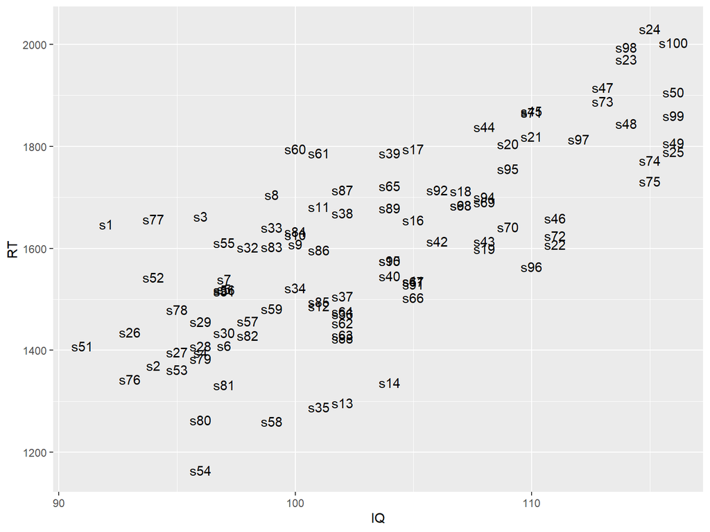

```r
ggplot(df, aes(x= IQ, y=RT)) + geom_text(aes(label = Participant))
```

## Layer: geom

- The same thing…
- Let’s declutter the plot a bit

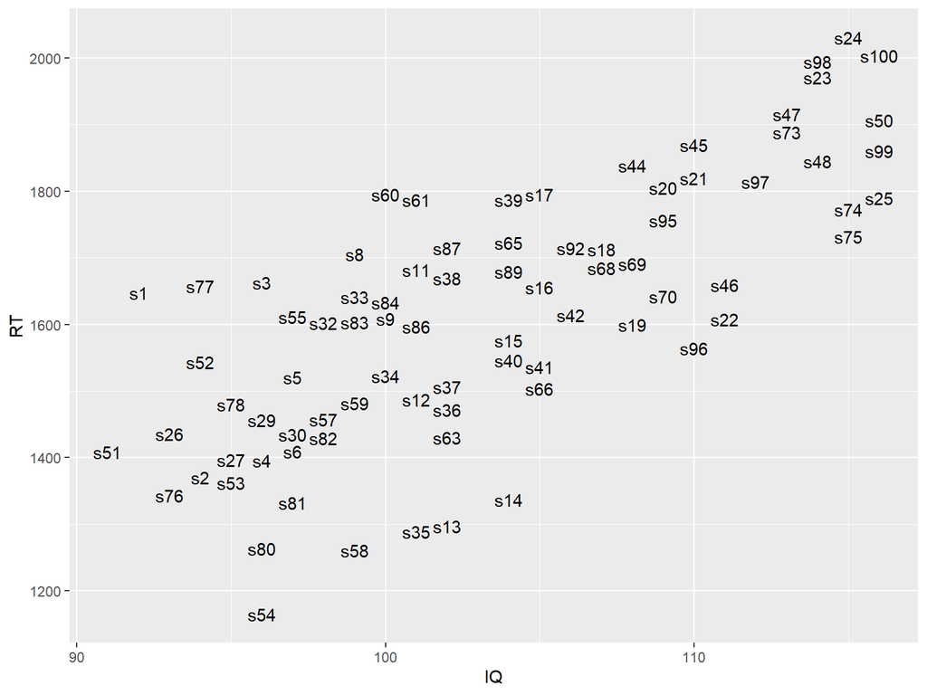

```r
ggplot(df, aes(x= IQ, y=RT)) + geom_text(aes(label = Participant), check_overlap = TRUE)
```

## Layer: geom

- Let’s go back to points and add a line

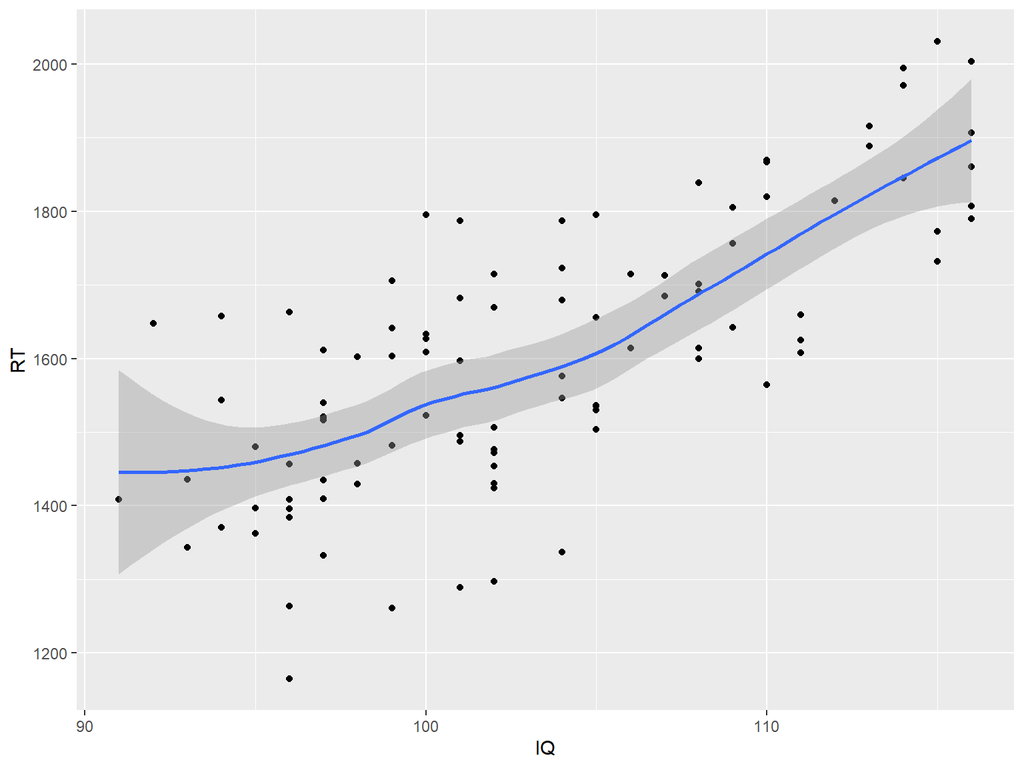

```r
ggplot(df, aes(x= IQ, y=RT)) + geom_point() + geom_smooth()
```

## Layer: geom

- Let’s add text somewhere, as we like

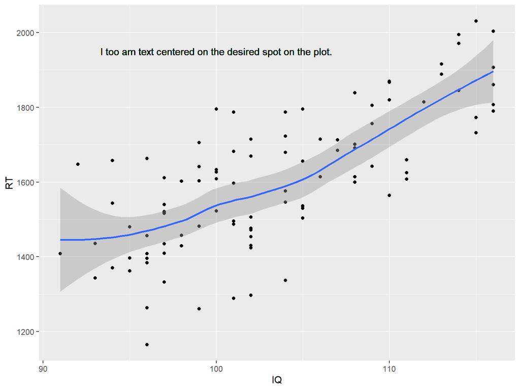

```r
ggplot(df, aes(x= IQ, y=RT)) + geom_point() + geom_smooth() +
  geom_text(aes(x=100, y=1950,label = "I too am text centered on the desired spot on the plot."))
```

## Let’s add a vertical line, horizontal line, arrow, text, shaded area

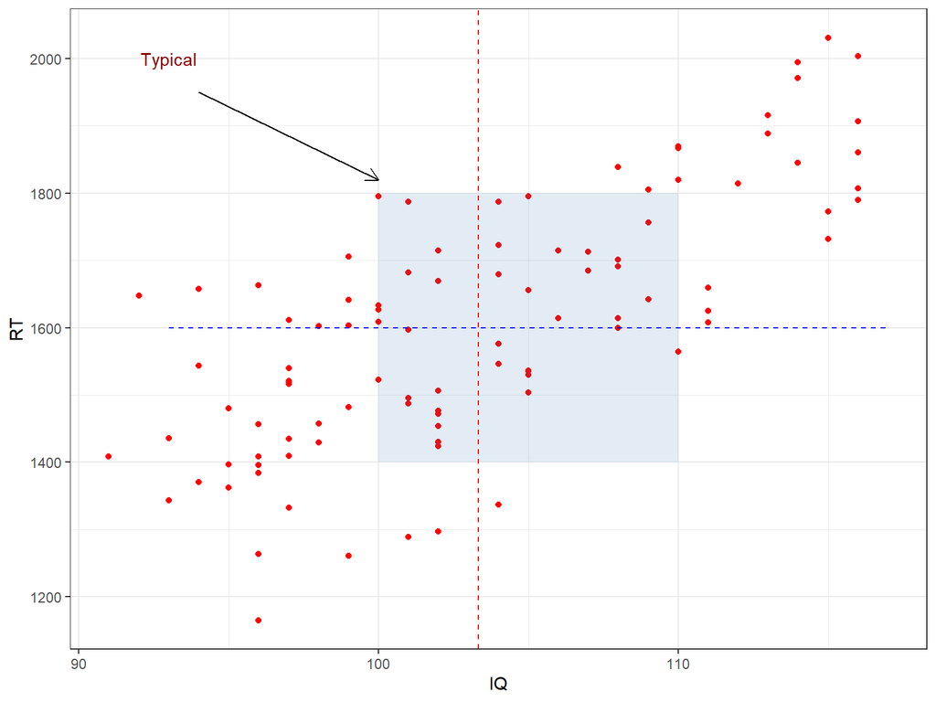

```r
g2 +
  annotate("rect", xmin = 100, xmax = 110,
           ymin = 1400, ymax = 1800,
           alpha = 0.15,
           fill = "steelblue") +
  annotate("segment", x = 93, xend = 117,
           y = 1600, yend = 1600,
           colour = "blue",
           linetype = "dashed") +
  annotate("segment", x = 94, xend = 100,
           y = 1950, yend = 1820,
           arrow = arrow(length = unit(0.3, "cm")),
           colour = "black") +
  annotate("text", x = 93, y = 2000,
           label = "Typical",
           colour = "darkred") +
  geom_vline(xintercept = mean(df$IQ),
           linetype="dashed",
           color="red")
```

## Layer: stat

## Layer: stat

- Each stat is closely tied to a geom
  - e.g. for stat_bin() the basic operation is counting (geom_bar, geom_histogram)

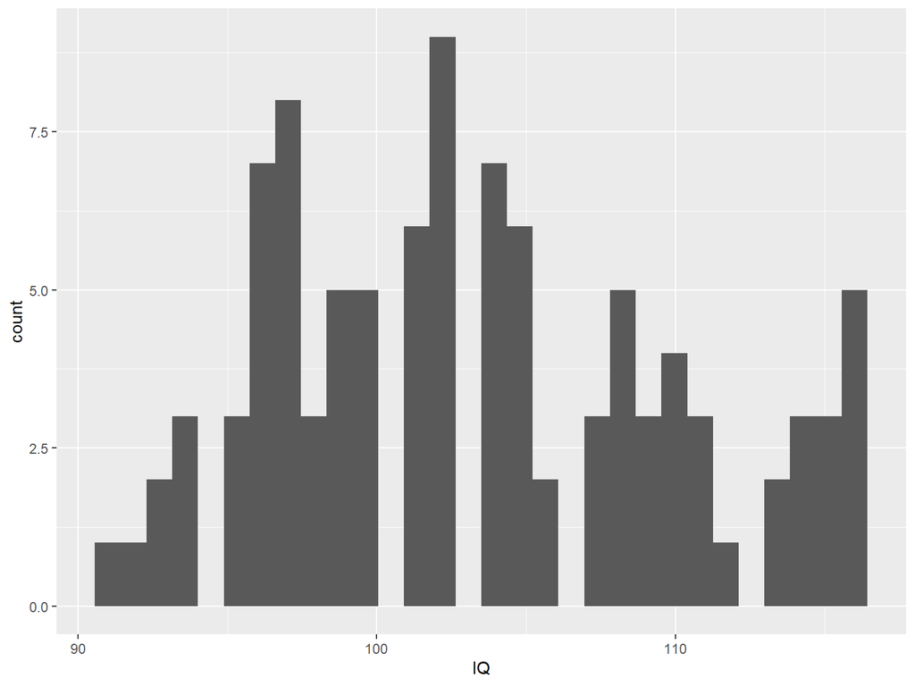

```r
ggplot(df, aes(IQ)) + stat_bin()
```

```r
# does the same as geom_bar() and geom_histogram,
# since both of these geoms rely on this stat (counting)
```

## Layer: stat

- stat_smooth() the basic operation is approximating a group of points (geom_smooth)

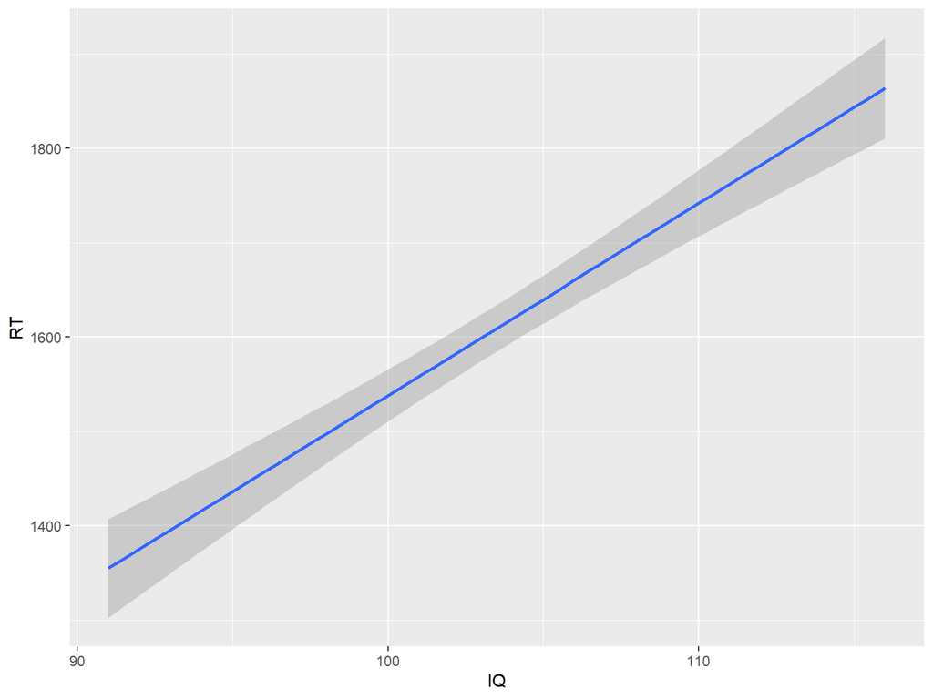

```r
ggplot(df, aes(IQ,RT)) + stat_smooth(method="lm")
```

```r
# does the same as geom_smooth(method="lm")
```

## Layer: stat

- let’s display averages by category

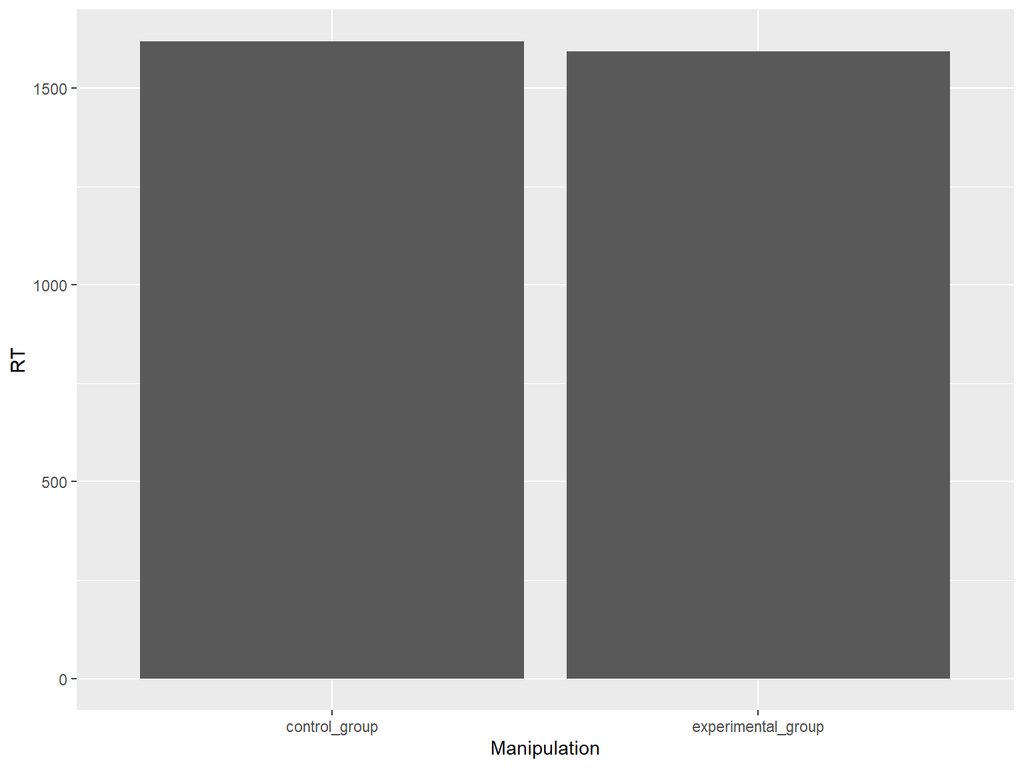

```r
ggplot(df, aes(x=Manipulation, y=RT)) +
  stat_summary(fun = mean, geom = "bar")
```

## Layer: stat

- let’s add a CI

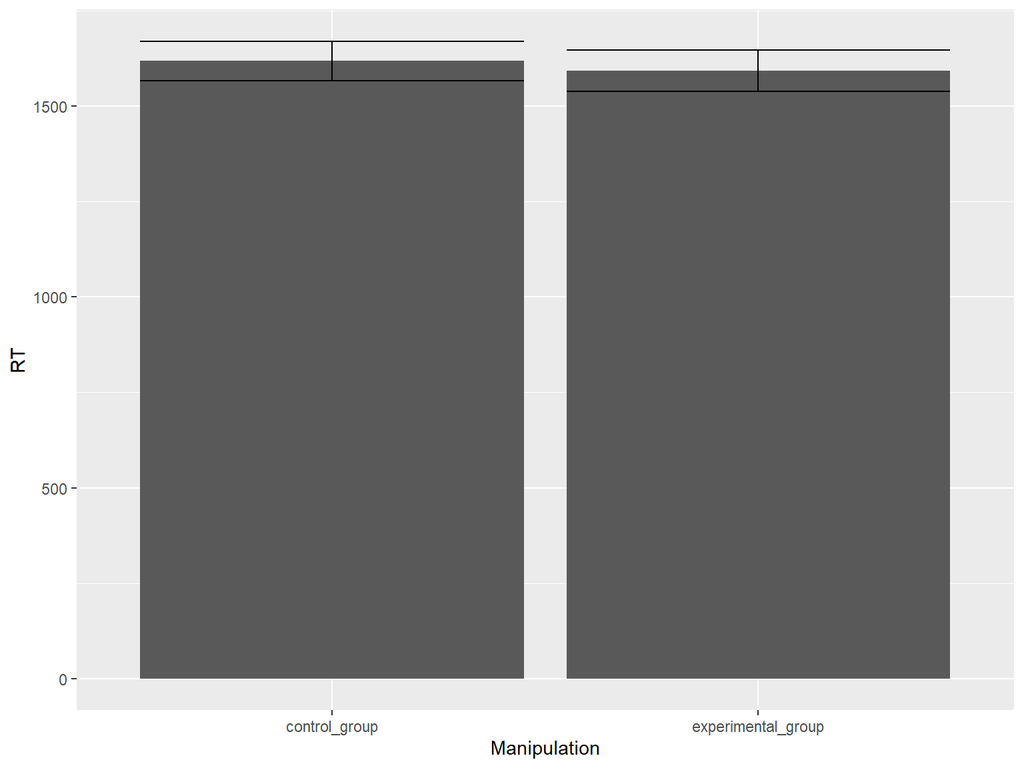

```r
ggplot(df, aes(x=Manipulation, y=RT)) +
  stat_summary(fun = mean, geom = "bar") +
  stat_summary(fun.data = mean_cl_normal, geom = "errorbar")
```

## Layer: position

## Layer: position

- I want to cross Manipulation with Handedness
  - Nothing is visible, because ggplot automatically stacks bars on top of each other (position = “stack”)

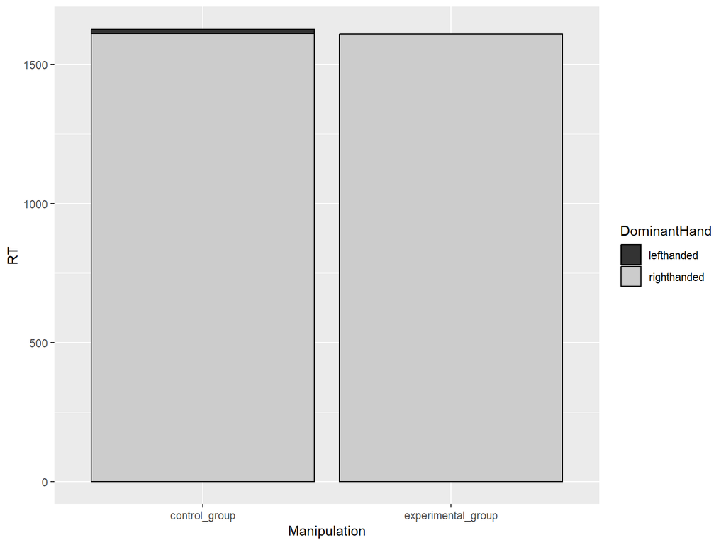

```r
ggplot(df, aes(x=Manipulation, y=RT, fill=DominantHand)) +
  stat_summary(fun = mean, geom = "bar", color="black") +
  scale_fill_grey() # so that the bars are in shades of grey, not clashing colors
```

## Layer: position

- To make them visible nicely, I need to place the bars side by side (position = “dodge”)

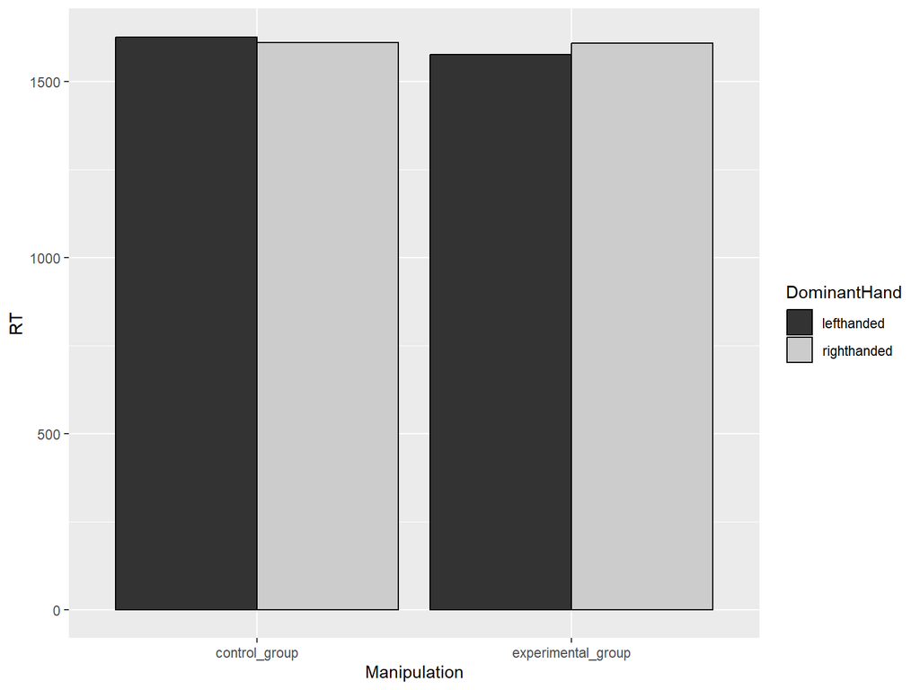

```r
ggplot(df, aes(x=Manipulation, y=RT, fill=DominantHand)) +
  stat_summary(fun = mean, geom = "bar", position = "dodge", color="black") +
  scale_fill_grey()
```

## Layer: position

- For anyone who doesn’t believe I’m moving them, here’s proof:

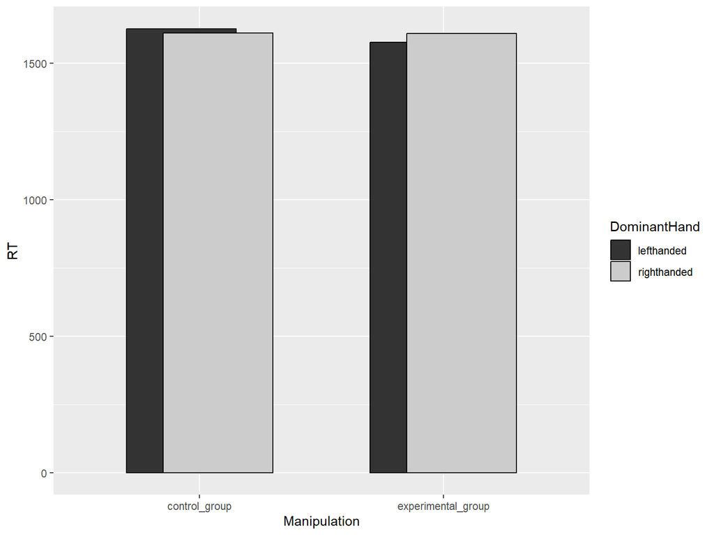

```r
ggplot(df, aes(x=Manipulation, y=RT, fill=DominantHand)) +
  stat_summary(fun = mean, geom = "bar",
               position = position_dodge(width = 0.30), color="black") +
  scale_fill_grey()
```

## Layer: position

- Let’s change the width of the bars

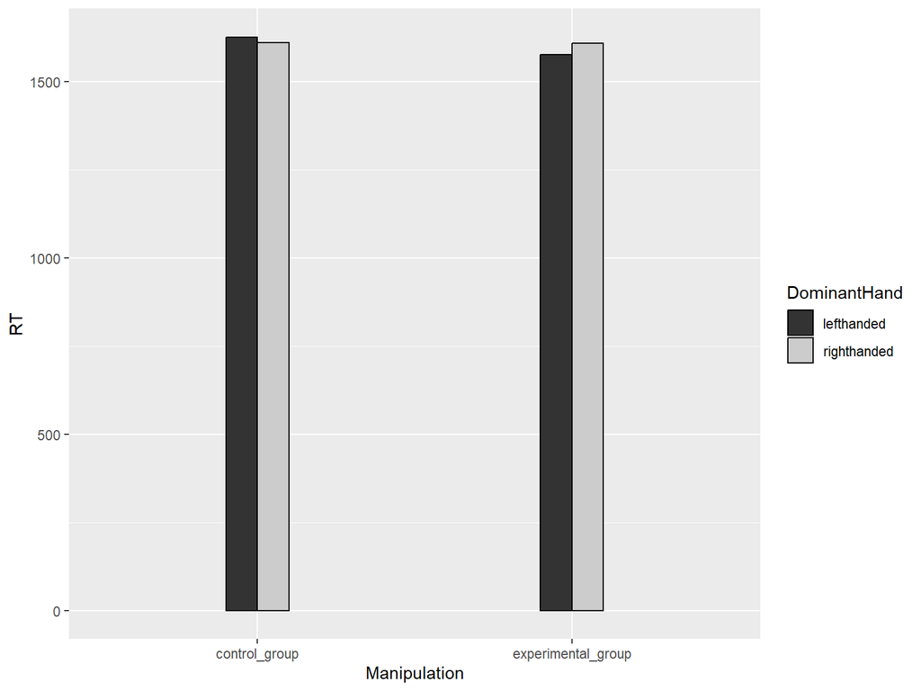

```r
ggplot(df, aes(x=Manipulation, y=RT, fill=DominantHand)) +
  stat_summary(fun = mean, geom = "bar", position = "dodge",
               width = 0.2, color="black") +
  scale_fill_grey()
```

## Layer: axes

## Layer: axes

- we’ve already seen this - give the plot a title:

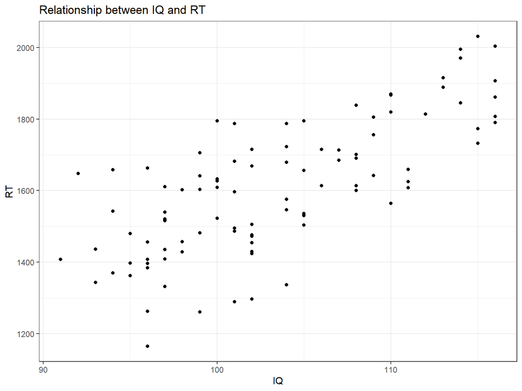

```r
g1 + ggtitle("Relationship between IQ and RT")
```

## Layer: axes

- We’ve already seen this - give the axes titles:

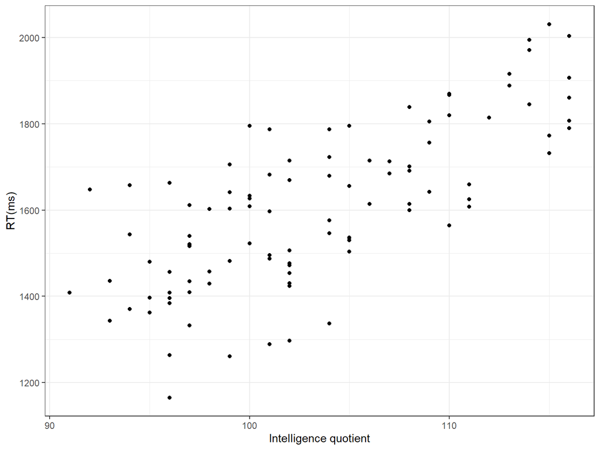

```r
g1 +
  xlab("Intelligence quotient") +
  ylab("RT(ms)")
```

## Layer: axes

- We can achieve the same thing with:

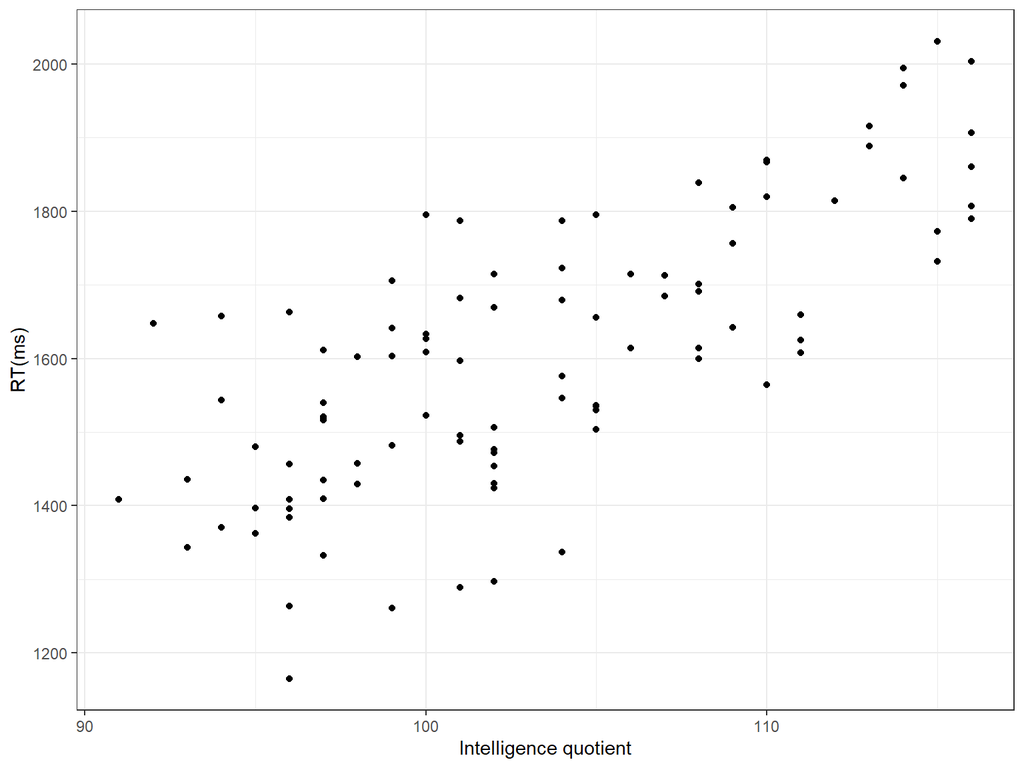

```r
g1 +
  scale_x_continuous("Intelligence quotient") +
  scale_y_continuous("RT(ms)")
```

## Layer: axes

- If there’s a categorical variable on the x-axis:

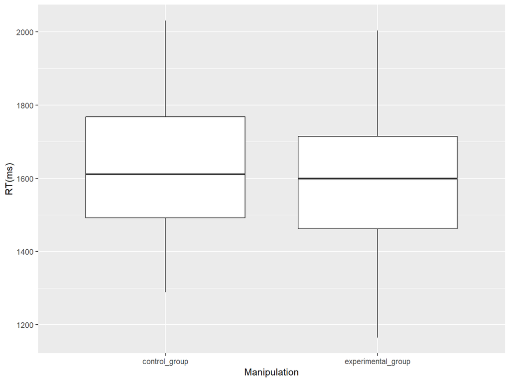

```r
g11 = ggplot(df, aes(x=Manipulation, y=RT)) +
  geom_boxplot() +
  scale_x_discrete(limits=c("control_group", "experimental_group")) +
  # this lets us arrange the levels in the order we want
  scale_y_continuous("RT(ms)")

g11
```